# Linear Models and Their Generalizations

Chapter 1 (continuation): Linear gaussian regression

Katia Meziani

## From now

Far sake of simplicity in the notation, we denote by $X=\mathbb{X}\in\mathbb{R}^{n\times p}$ the *design* matrix, $\beta=\boldsymbol{\beta}\in\mathbb{R}^p$ the unknown regression coefficient vector, $\epsilon=\boldsymbol{\epsilon}\in\mathbb{R}^n$ the theoretical residuals.

From now, we denote by $Y=X\beta+\epsilon$, the linear gaussian model such that

✍ where $X$ is the *design* matrix of size $n\times p$ (we consider $X_1=\mathbf{1}_n$).  
✍ We assume $X$ is full rank $p$.  
✍ $\widehat{\beta}$ denotes the OLS estimator and  
✍ $\widehat\sigma^2=\frac{\|Y-X\widehat{\beta}\|^2}{n-p}$.  
✍ We assume assumption **[P1]**–**[P4]** satisfied.  
✍ $\overline Y=n^{-1}\sum_{i=1}^nY_i$ and $\widehat Y=X\widehat{\beta}$, where the $Y_i$ are the observations.

# 4. Inference in the Gaussian linear regression model

## 4.1. *Nested* Theorem

**[(Nested) Theorem 5]**:

Let us consider the linear regression model $Y=X\beta+\epsilon$. Assume $X$ is full rank and **[P1]**–**[P4]**. Let $\widehat\sigma^2$ the unbiased estimator of $\sigma^2$ and $\widehat{\beta}$ the LSE

- Let $V\subset W$ be two nested subspaces of $\mathbb{R}^n$ with $q=\mbox{dim}(V)<s=\mbox{dim}(W)< n.$
- If $X\beta\in V\subset W$, then $F\sim\text{F}_{(s-q,n-s)}\quad\text{Fisher's law}$
  $$F:=\frac{(\|Y-P_V
  Y\|^2-\|Y-P_WY\|^2)/(s-q)}{\|Y-P_WY\|^2/(n-s)}=\frac{\|P_WY-P_VY\|^2/(s-q)}{\|Y-P_WY\|^2/(n-s)}$$
  where $P_V$ and $P_W$ are respectively the orthogonal projections onto $V$ and $W$.

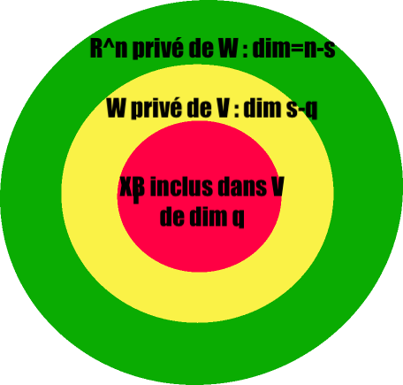

*Proof.*

Define $A:=\sigma^{-2}\|P_WY-P_VY\|^2$ and $B:=\sigma^{-2}\|Y-P_WY\|^2$ such that
$$F=\frac{\|P_WY-P_VY\|^2/(s-q)}{\|Y-P_WY\|^2/(n-s)}:=\frac{A/(s-q)}{B/(n-s)}$$
Note that, $Y-P_VY=(Y-P_WY)+(P_WY-P_VY)$ and

- $(Y-P_WY)=(\mathbf{I}_n-P_W)Y=P_{W^\perp}Y\in W^\perp$
- $(P_WY-P_VY)=(P_W-P_V)Y=P_{W/V}Y\in W/V$

Then
$$\|Y-P_VY=\|^2=\|Y-P_WY\|^2+\|P_WY-P_VY\|^2$$

Moreover, as $\ X\beta\in V\subset W$, it comes $P_VY=P_VX\beta+P_V\epsilon=X\beta+P_V\epsilon$ and $P_WY=P_WX\beta+P_W\epsilon=X\beta+P_W\epsilon$
$$\begin{array}{l}
P_WY-P_VY=(P_W-P_V)Y=(P_W-P_V)\,\epsilon\in (W/V)\in W\\
Y-P_WY=(\textbf{I}_n-P_W)Y=P_{W^\perp}\epsilon\in W^\perp
\end{array}$$

Then as $\epsilon$ is gaussian, by Cochran theorem
$$A:=\sigma^{-2}\|P_WY-P_VY\|^2\sim
\chi^2_{(s-q)},\quad\text{and}\quad
B=\sigma^{-2}\|Y-P_WY\|^2\sim\chi^2_{(n-s)},$$
and as $A$ independant of $B$, it comes $F=\frac{\chi^2_{(s-q)}/(s-q)}{\chi^2_{(n-s)}/(n-s)}\sim \text{F}_{(s-q,n-s)}.$$\square$.

## 4.2 Confidence intervals/regions

**[Proposition 6]**:

Assume $X$is full rank $p$ and **[P1]**–**[P4]**. Let $\alpha\in]0,1[$. For any $c\in\mathbb{R}^p$, the follwing is an exact $1-\alpha$ level confidence interval for $c^\top{\beta}$:
$$c^\top{\beta}\in\left[c^\top \widehat{\beta} \;\pm \;
q^{t_{n-p}}_{1-\alpha/2}\;\widehat\sigma\;\sqrt{c^\top (X^\top
X)^{-1}c}\right],$$
where $q^{t_{n-p}}_{1-\alpha/2}$ is the quantile of order $1-\alpha/2$ of the $t$-distribution $t_{n-p}$.

*Proof.* By theorem 4, Therefore
$$A:=\frac{c^\top\widehat\beta-c^\top\beta}{\sqrt{\widehat\sigma^2c^\top(X\top
X)^{-1}c}}\sim t_{n-p}$$
Then,
$$\text{P}_\beta\left(-q^{t_{n-p}}_{1-\alpha/2}\leq A \leq
q^{t_{n-p}}_{1-\alpha/2}\right)
=\text{P}_\beta\left(c^\top\beta\in\left[c^\top \widehat{\beta} \;\pm \;
q^{t_{n-p}}_{1-\alpha/2}\;\widehat\sigma\;\sqrt{c^\top (X^\top
X)^{-1}c}\right]\right)\square$$

**[Corollary 1]**: Consider the linear gaussian model $Y=X\beta+\epsilon$, under the Rank assumption and under **[P1]**–**[P4]**, let $\widehat\sigma^2$ be the unbiased estimator and $\widehat{\beta}$ the OLS estimator. Let $\alpha\in]0,1[$. Then for all $j=1,\cdots,p$
$$\beta_j\in\left[\widehat{\beta}_j\; \pm \;
q^{t_{n-p}}_{1-\alpha/2}\widehat\sigma\sqrt{(X^\top
X)^{-1}_{jj}}\right],$$
where $q^{t_{n-p}}_{1-\alpha/2}$ is the quantile of order $1-\alpha/2$ of $t_{(n-p)}$.

*Proof.* Direct application of the proposition 6 with $c\in\mathbb{R}^p$ such that $c_k=0$ for all $k\neq j$ et $c_j=1$. $\square$

**Ⓡ** Display the confidence interval for $\beta_j$

```r
mod<-lm(maxO3~.,data=Ozone)
cbind(mod$coefficient,confint(mod, level = 0.95))
```

```
##                               2.5 %     97.5 %
## (Intercept) 12.24441987 -14.4802083 38.9690481
## T9          -0.01901425  -2.2510136  2.2129851
## T12          2.22115189  -0.6214249  5.0637287
## T15          0.55853087  -1.7121182  2.8291799
## Ne9         -2.18909215  -4.0502993 -0.3278850
## Ne12        -0.42101517  -3.1340934  2.2920630
## Ne15         0.18373097  -1.8055357  2.1729977
## Vx9          0.94790917  -0.8618028  2.7576211
## Vx12         0.03119824  -2.0620871  2.1244836
## Vx15         0.41859252  -1.3978619  2.2350470
## maxO3v       0.35197646   0.2272237  0.4767292
```

**[Proposition 7]**:

Assume $X$ is full rank and **[P1]**–**[P4]**. Let $\alpha\in]0,1[$. The follwing is an exact $1-\alpha$ level confidence interval for $\sigma^2$:
$$\left[\frac{(n-p)\widehat\sigma^2}{q^{\chi^2_{(n-p)}}_{1-\alpha/2}}\ , \
\frac{(n-p)\widehat\sigma^2}{q^{\chi^2_{(n-p)}}_{\alpha/2}}\right]$$
where $q^{\chi^2_{(n-p)}}_{1-\alpha/2}$ and $q^{\chi^2_{(n-p)}}_{\alpha/2}$ are the quantile of order $(1-\alpha/2)$ and $\alpha/2$ of the $\chi^2_{(n-p)}$ distibution.

*Proof.* . Immediate as by Theorem 4,
$$\mathcal{X}:=\frac{(n-p)\widehat\sigma^2}{\sigma^2}\sim\chi^2(n-p)\square$$

```r
n <- length(Ozone$maxO3)
p <- length(coef(mod))
alpha <- 0.05

sigma2_hat <- summary(mod)$sigma^2

IC_sigma2 <- sigma2_hat * c((n - p) / qchisq(1 - alpha / 2, n - p),
                               (n - p) / qchisq(alpha / 2, n - p))

cat("estimation of sigma : ", sigma2_hat,"\n")
```

```
## estimation of sigma :  206.2102
```

```r
cat("Intervalle de confiance pour sigma^2 (95%) : [", IC_sigma2[1], ", ", IC_sigma2[2], "]\n")
```

```
## Intervalle de confiance pour sigma^2 (95%) : [ 159.3518 ,  277.3877 ]
```

**[Proposition 8]**:

Assume $X$ is full rank and **[P1]**–**[P4]**. Let $\alpha\in]0,1[$. Let $C$ be a matrix of size $q\times p$ and rank $q\leq p$. Then the following is an exact $1-\alpha$ level confidence region for $C\beta$:
$$R=\left\{a:\quad \frac{(C\widehat{\beta}-C\beta)^\top (C(X^\top
X)^{-1}C^\top )^{-1}(C\widehat{\beta}-C\beta)}{q\widehat\sigma^2}\leq
q^{\text{F}_{(q,n-p)}}_{1-\alpha}
\right\}$$
with $q^{\text{F}_{(q,n-p)}}_{1-\alpha}$ the quantile of order $1-\alpha$ of the Fisher distribution $\mathcal{F}(q,n-p)$.

*Proof.* Immediate as by Theorem 4,
$$\frac{(C\widehat{\beta}-C\beta)^\top (C(X^\top X)^{-1}C^\top
)^{-1}(C\widehat{\beta}-C\beta)}{q\widehat\sigma^2}\sim{\text{F}}_{(q,n-p)}.$$

# 5. Hypothesis testing

## 5.1. Test: $\mathcal{H}_0:\,c^\top{\beta}=a$

For $c\in\mathbb{R}^p$ and $a\in\mathbb{R}$, we want to test hypotheses
$$\mathcal{H}_0:\,c^\top{\beta}=a \ vs \
\mathcal{H}_1:\,c^\top{\beta}\not= a$$
.

**[Theorem 6]**: Let $c\in\mathbb{R}^p$ and $\alpha\in]0,1[$. We consider the hypothesis
$$\mathcal{H}_0: \
c^\top{\beta}=a\quad\mbox{vs}\quad \mathcal{H}_1: \ c^\top{\beta}\not=
a.$$

The following test admits type-I error of size $\alpha$:
$$\phi(Y)=1_{\{|T|>q^{t_{n-p}}_{1-\alpha/2}\}}\quad
\mathrm{with} \quad T:=\frac{c^\top
\widehat{\beta}-a}{\widehat\sigma\sqrt{c^\top (X^\top
X)^{-1}c}},$$
and $q^{t_{n-p}}_{1-\alpha/2}$ is the quantile of order $1-\alpha/2$ of $t_{(n-p)}$.

*Proof.* By theorem 4 and under $\mathcal{H}_0:\,c^\top{\beta}=a$
$$T:=\frac{c^\top\widehat\beta-a}{\sqrt{\widehat\sigma^2c^\top(X\top
X)^{-1}c}}\sim t_{n-p}$$
Then,
$$\text{P}_{a}\left(|A_0|> q^{t_{n-p}}_{1-\alpha/2}\right) =\alpha. \
\square$$
📌 This framework covers the following case:
$$\mathcal{H}_0: \, \beta_j=0 \ vs \ \mathcal{H}_1: \,
\beta_j\not=0,\qquad j\in\{1,\ldots,p\}.$$
This test is used to determine whether a covariate $X_j$ has an impact on response variable $Y$.

Declare our linear model and display with **Ⓡ**

```r
library(kableExtra)
mod<-lm(maxO3~.,data=Ozone)
summary(mod)%>%coefficients()%>%kbl()
```

|  | Estimate | Std. Error | t value | Pr(>\|t\|) |
| --- | --- | --- | --- | --- |
| (Intercept) | 12.2444199 | 13.4719013 | 0.9088858 | 0.3655741 |
| T9 | -0.0190143 | 1.1251522 | -0.0168993 | 0.9865503 |
| T12 | 2.2211519 | 1.4329447 | 1.5500612 | 0.1242547 |
| T15 | 0.5585309 | 1.1446356 | 0.4879552 | 0.6266392 |
| Ne9 | -2.1890921 | 0.9382356 | -2.3332008 | 0.0216199 |
| Ne12 | -0.4210152 | 1.3676644 | -0.3078352 | 0.7588417 |
| Ne15 | 0.1837310 | 1.0027906 | 0.1832197 | 0.8549930 |
| Vx9 | 0.9479092 | 0.9122769 | 1.0390586 | 0.3012586 |
| Vx12 | 0.0311982 | 1.0552264 | 0.0295654 | 0.9764720 |
| Vx15 | 0.4185925 | 0.9156758 | 0.4571405 | 0.6485518 |
| maxO3v | 0.3519765 | 0.0628879 | 5.5968846 | 0.0000002 |

📈 The output you get from `summary(mod)$coefficients` in *R* provides a detailed summary of the estimated coefficients in your linear regression model.

- `Estimate` This column shows the estimated coefficients $\widehat\beta_j$ for each predictor variable in your model. These coefficients represent the expected change in the response variable (`maxO3` in your case) for a one-unit change in the predictor, assuming all other predictors are held constant. For example, the estimate for `T12` is `2.22115`, which means that for each additional unit increase in `T12`, the `maxO3` is expected to increase by `2.22115` units, assuming all other variables are held constant.
- `Std. Error` **(Standard Error)** This column provides the standard error of the estimated coefficients. The standard error measures the variability of the coefficient estimate; it indicates how much the estimated coefficient would vary if the model were fitted to a different sample from the same population. For instance, the standard error for `T12` is `1.43294`, meaning there’s some variability in how precise the `2.22115` estimate is:
  $$\text{Std.
  Error}[\widehat{\beta_j}]=\sqrt{\text{E}_{\beta}[(\widehat{\beta_j}-\beta_j)^2]}=\widehat{\sigma^2}(\mathbb{X}^\top\mathbb{X})^1_{jj},\
  \quad j=1,\cdots 11$$
  As $\widehat{{\beta}}$ is unbiased and of variance $\sigma^2(X^\top X)^1$, then
  $$\text{E}_{{{\beta}}}[(\widehat{\beta_j}-\beta_j)^2]=\text{Var}_{{{\beta}}}[\widehat{\beta_j}]=\sigma^2(
  X^\top X)^1_{jj},\ \quad j=1,\cdots 11$$
- `t value` is the value of $T:=\frac{\widehat\beta_j-a}{\sqrt{\widehat\sigma^2c^\top(X\top X)^{-1}c}}\sim t_{n-p}$ associated to the t-test
  $$\mathcal{H}_0: \, \beta_j=0 \ vs \ \mathcal{H}_1: \,
  \beta_j\not=0,\qquad j\in\{1,\ldots,11\}.$$
  It measures how many standard deviations the coefficient is away from zero. A higher absolute t-value indicates that the predictor is more strongly associated with the response variable. For example, the t-value for `maxO3v` is `5.597`, which is quite high, indicating a strong relationship between `maxO3v` and `maxO3`.
- `Pr(>|t|)` is the **(p-value)** associated with the t-test for each coefficient. The p-value indicates the probability of observing the data if the null hypothesis (that the coefficient is zero, meaning no effect) were true. A small p-value (typically less than 0.05) suggests that you can reject the null hypothesis, meaning the predictor likely has a significant effect on the response variable. For example, the p-value for `maxO3v` is very small (`1.88e-07`), suggesting that `maxO3v` is a statistically significant predictor of `maxO3`.

## 5.2. Global Fisher test

The **Global Fisher test** is used to test the utility of regressors:
$$\mathcal{H}_0:
\,Y=\beta_1\textbf{1}_n+\epsilon\ vs \ \mathcal{H}_1:
\,Y=\beta_1\textbf{1}_n+\sum_{j=2}^{p}\beta_jX_j+\epsilon.$$
Here, we test under $\mathcal{H}_0$ the model reduced to the intercept against the full model under $\mathcal{H}_1$. so it is equivalent to test
$$\mathcal{H}_0: \, X\beta\in
[\textbf{1}_n]\ vs \ \mathcal{H}_1: \, X\beta\in [X].$$

**[Theorem 7 (Global Fisher test)]**:

We want to test hypotheses
$$\mathcal{H}_0: \, X\beta\in [\textbf{1}_n]\ vs \ \mathcal{H}_1: \,
X\beta\in [X].$$
The following test admits type-I error of size $\alpha\in(0,1)$:
$$\phi(Y)=1_{\{F>q^{\text{F}_{p-1,n-p}}_{1-\alpha}\}},$$
where
$$F:=\frac{\|\overline{Y}\textbf{1}_n-\widehat{Y}\|^2/(p-1)}{\|Y-\widehat{Y}\|^2/(n-p)}$$
where $q^{\text{F}_{p-1,n-p}}_{1-\alpha}$ is the quantile of order $1-\alpha$ of the Fisher law at $(p-1,n-p)$ degrees of freedom.

*Proof.* Immediate by using the Nested theorem. Indeed, the **Global Fisher test** compare the 2 nested model: intercept model and the full model. Then by the Nested theorem with $V=[\textbf{1}_n]$ and $W=[X]$ such that $V\subset W\subset \mathbb{R}^n$ and with $1=\mbox{dim}(V)<p\mbox{dim}(W)$, the Global Fisher test can be rewritten
$$\mathcal{H}_0: \, X\beta\in V\subset W\ vs \ \mathcal{H}_1: \, X\beta\in
W.\ \square$$

Under **Ⓡ** , the `summary` displays the Global Fisher test

```r
F-statistic: 32.67 on 10 and 101 DF,  p-value: < 2.2e-16
```

📈 Here the `p-value: < 2.2e-16` is small, then we reject $\mathcal{H}_0$, the model is not resumed to the intercept, at least one covariate is useful.

## 5.3. Fisher test for nested models

**[Theorem 8 (Fisher test for nested models)]**:

We want to test hypotheses
$$\mathcal{H}_0: \, X\beta\in V\subset W\ vs \ \mathcal{H}_1: \, X\beta\in
W.$$
The following test admits type-I error of size $\alpha\in(0,1)$:
$$\phi(Y)=1_{\{F>q^{\text{F}_{p-q,n-p}}_{1-\alpha}\}},$$
where
$$F:=\frac{\|P_VY-P_WY\|^2/(p-q)}{\|Y-P_WY\|^2/(n-p)}$$
with $P_V$ and $P_W$ respectively the orthogonal projections onto $V$ and $W$ and $q^{\text{F}_{p-q,n-p}}_{1-\alpha}$ is the quantile of order $1-\alpha$ of the Fisher law at $(p-q,n-p)$ degrees of freedom.

*Proof.* Immediate using the Nested theorem. $\square$

**Ⓡ** Consider 2 nested models
$$\left\{\begin{array}{l}
\text{mod}_1:\, \text{maxO3=T9+Ne9+Vx9+maxO3v}+\epsilon,\\
\text{mod}_2:\, \text{maxO3=T9+T12+Ne9+Ne12+Vx9+Vx12+maxO3v}+\epsilon
\end{array}\right.$$
and display the nested Fisher test
$$\left\{\begin{array}{l}
\mathcal{H}_0: \, \text{mod}_1 \text{ is adequat}\\
\mathcal{H}_1: \, \text{mod}_2 \text{ is adequat}
\end{array}\right.$$

```r
mod_1<-lm(maxO3~T9+Ne9+Vx9+maxO3v,data=Ozone)
mod_2<-lm(maxO3~T9+T12+Ne9+Ne12+Vx9+Vx12+maxO3v,data=Ozone)

anova(mod_1,mod_2)
```

|  | Res.Df | RSS | Df | Sum of Sq | F | Pr(>F) |
| --- | --- | --- | --- | --- | --- | --- |
| 1 | 107 | 23263.33 | NA | NA | NA | NA |
| 2 | 104 | 20913.52 | 3 | 2349.808 | 3.895088 | 0.01106 |

📈 Here $F$=`3.8951`and the $p$-*value*=`0.01106`is less than 5% then we reject `mod_1` at level 5%.

# 6. $R^2$-coefficient

In this section, we consider the model
$$Y=X\beta+\epsilon,\quad \text{with}\quad X = \left[\textbf{1}_n \ X_2 \
\cdots \ X_p\right]$$
We assume $X$ is full rank $p$ and **[P1]**–**[P3]** satisfied.

**[Variability]**

We define by

- $\text{TSS}:=\|y-\overline y \textbf{1}_n\|^2=\sum_{i=1}^n(y_i-\overline y)^2$ : the total sum of squares
- $\text{RSS}:=\|y-\widehat y\|^2=\sum_{i=1}^n(y_i-\widehat y_i)^2$ : the residual sum of squares
- $\text{MSS}:=\|\widehat y- \overline y\textbf{1}_n\|^2=\sum_{i=1}^n(\widehat y_i-\overline y)^2$ : the model sum of squares by the model

📝 The $\text{TSS}$ corresponds to the total variability (variance).  
📝 The $\text{RSS}$ corresponds to the variability (variance) not explained by the model.  
📝 $\text{MSS}$ corresponds to the variability (variance) explained by the model.

**[Proposition 9]**: Relation between $\text{RSS}$, $\text{TSS}$ and $\text{MSS}$ is such that
$$\text{TSS}=\text{MSS}+\text{RSS}$$

*Proof.* As $(Y-\widehat Y )\in [X]^{\perp}$ and $(\widehat Y-\overline Y\textbf{1}_n )\in[X]$ are orthogonal vectors, we get by Pythagoras formula
$$\|Y-\overline Y\textbf{1}_n \|^2=\| Y-\widehat Y+\widehat Y-\overline
Y\textbf{1}_n\|^2= \|Y-\widehat Y \|^2+\|\widehat Y-\overline
Y\textbf{1}_n \|^2\quad\square$$

📌If the model is “good” enough, the part of total variability must be explained by the model and inversely the part of variability not explained by the model shall be small. It is the role of the determination coefficient to quantify this notion.

**$R^2$ coefficient**

We define the **determination coefficient $R^2$** as follows
$$R^2=\frac{\text{MSS}}{\text{TSS}}=\frac{\|\widehat y-\overline y
\textbf{1}_n\|^2}{\|y-\overline y
\textbf{1}_n\|^2}=1-\frac{\text{RSS}}{\text{TSS}}.$$

**COMMENTS**

📝 Note that $R^2\in[0,1]$. $\ R^2$-coefficient close to 1 “*means”* the predictors $X_2,\ldots,X_p$ *“well”* explain the model, *i.e.* the model *fits* well.

📝 The linear model is interesting only if the errors $(y_i-\widehat y_i)$ are small relative to the errors $(y_i-\overline{y}_i)$ that we would make if we took a model without regressors, *i.e.* a model reduced to the intercept. The linear model has an interest if
$$\frac{\text{RSS}}{\text{TSS}}=\frac{\|y-\widehat y\|^2}{\|y-\overline y
\textbf{1}_n\|^2}\to_{p\to\infty}0
\Leftrightarrow R^2\to_{p\to\infty}1.$$

📝 Note that for the global Fisher test,
$$F=\frac{\|P_XY-\overline
Y\textbf{1}_n\|^2/(p-1)}{\widehat\sigma^2}=\frac{(n-p)R^2}{(p-1)(1-R^2)}$$
Thus, $\mathcal{H}_0$ is rejected for large values of $R^2$.

😕 The $R^2$-coefficient increases with the number of predictors $p$ (equivalentely $\text{RSS}$ decrease with $p$). Indeed,
$$\begin{align*}
\text{RSS}({p+1})
&=\|Y-X\widehat{\beta}\|^2=\min_{\beta\in\mathbb{R}^{p+1}}\|Y-X\beta\|^2
=\min_{\beta\in\mathbb{R}^{p+1}}\|Y-\sum_{j=1}^{p+1}X_j\beta_j\|^2\\
&\leq
\min_{\beta\in\mathbb{R}^{p}}\|Y-\sum_{j=1}^{p}X_j\beta_j\|^2=\text{RSS}(p)
\end{align*}$$
$R^2$-coefficient is not a good criterion to compare models!

**We need to correct the dependence on the dimension $p$ $\Rightarrow$ adjusted $R^2$.**

**Adjusted coefficient**

We define the **adjusted determination coefficient $R^2_a$** as follows
$$R^2_a=1-\frac{(n-1)\|Y-\widehat
Y\|^2}{(n-p)\|Y-\overline
Y\textbf{1}_n\|^2}=1-\frac{(n-1)\|\widehat{\epsilon}\|^2}{(n-p)\|Y-\overline
Y\textbf{1}_n\|^2}.$$

📝 Note that $R^2_a\in[0,1]$. $R^2_a$-coefficient close to 1 *“means”*the predictors $X_2,\ldots,X_p$ *“well”* explain the model.

Let display these coefficient with **Ⓡ**

```r
cat("Multiple R-squared:", summary(mod)$r.squared, ", Adjusted R-squared:", summary(mod)$adj.r.squared, "\n")
```

```
## Multiple R-squared: 0.7638413 , Adjusted R-squared: 0.7404593
```

# 7. Prediction

## 7.1. Fitted values

**[Corollary 2]**:

Assume $X$ is full rank and **[P1]**–**[P4]**. Let $\alpha\in]0,1[$. Let $\alpha\in]0,1[$ and . For any $x_0=(x_{01},\cdots,x_{0p})^\top \in\mathbb{R}^p$, the follwing is an exact $1-\alpha$ level confidence interval for $\text{E}_{\beta}[Y_0] = x_0^\top{\beta}$
$$x_0^\top{\beta}\in \left[ x_0^\top \widehat{\beta}\; \pm
\,\;q^{t_{n-p}}_{1-\alpha/2}\widehat\sigma\sqrt{x_0^\top (X^\top
X)^{-1}x_0} \right],$$
where $q^{t_{n-p}}_{1-\alpha/2}$ is the quantile of order $1-\alpha/2$ of $t_{(n-p)}$.

*Proof.* Direct application of the proposition 6 with $x_0\in\mathbb{R}^p$. $\square$

Note that with **Ⓡ** , we can display the fitted values $\widehat Y_i$

```r
haty<-predict(mod,data=Ozone)
# or equivalently
#haty<-mod$fitted.values
y<-Ozone$maxO3
cbind.data.frame(y,haty)%>%rmarkdown::paged_table()
```

|  | y | haty |
| --- | --- | --- |
| 1 | 87 | 84.22583 |
| 2 | 82 | 76.04879 |
| 3 | 92 | 88.12804 |
| 4 | 114 | 98.90342 |
| 5 | 94 | 86.99312 |
| 6 | 80 | 76.80700 |
| 7 | 79 | 60.09668 |
| 8 | 79 | 83.30354 |
| 9 | 101 | 88.18417 |
| 10 | 106 | 96.37598 |

[output cut: 102 more lines]

## 7.2. New observation

A new individual $(x_{n+1},Y_{n+1})$ appears but we are only provided with the values of the regressors $x_{n+1}=(x_{n+1,1},\ldots,x_{n+1,p})^\top$ but not with the corresponding response variable $Y_{n+1}$.

**Objective** Predict $Y_{n+1}$ where $Y_{n+1}=x_{n+1}^\top{\beta}+\epsilon_{n+1}$ and $\epsilon_{n+1}$ is a $r.v.$ independent of $(\epsilon_i)_{1\leq i\leq n}$ and that admits the same distribution as the $\epsilon_i$’s.

💡 **Method**

Estimate $\beta$ by $\widehat{\beta}$ which is a function of $(Y_1,\ldots,Y_n)$.

Then, we estimate $Y_{n+1}$ by $\widehat Y_{n+1}=x_{n+1}^\top \,\widehat{\beta}.$ Note that
$$\text{E}_{\beta}[\widehat Y_{n+1}]=x_{n+1}^\top{\beta},\quad
\text{Var}_{\beta}(\widehat Y_{n+1})=\sigma^2(x_{n+1}^\top (X^\top
X)^{-1}x_{n+1}).$$

**[Theorem 9]**:

Under the Rank assumption and under **[P1]**–**[P4]**. Set $\alpha\in (0,1)$. The following is an $1-\alpha$ confidence interval for $Y_{n+1}$:
$$Y_{n+1}\in\left[x_{n+1}^\top \widehat{\beta}\; \pm
\;q^{t_{n-p}}_{1-\alpha/2}\widehat\sigma\sqrt{1+x_{n+1}^\top (X^\top
X)^{-1}x_{n+1}}\right],$$
where $q^{t_{n-p}}_{1-\alpha/2}$ is the quantile of order $1-\alpha/2$ for $t_{(n-p)}$.

*Sketch of Proof.*

$$\text{As} \
Y_{n+1}:=x_{n+1}^\top\beta+\epsilon_{n+1}\quad \text{and}\quad
Y_{n+1}\sim \mathcal{N}(x_{n+1}^\top\beta,\sigma^2)$$
and as $\widehat Y_{n+1}=x_{n+1}^\top \,\widehat{\beta}$ and under the full rank assumption and **[P1]**–**[P4]**, it comes by Proposition 4
$$x_{n+1}^\top(\widehat{\beta}-\beta)x_{n+1}\sim
\mathcal{N}(0,\sigma^2x_{n+1}^\top(X^\top X)^{-1}x_{n+1})$$
Morevover, $\epsilon_{n+1}$ is independant of $\epsilon$ $\Rightarrow$ $\epsilon_{n+1}$ is independant of $\widehat{\beta}$. Compute
$$Y_{n+1}-\widehat
Y_{n+1}=x_{n+1}^\top\beta+\epsilon_{n+1}-x_{n+1}^\top\widehat{\beta}=\epsilon_{n+1}-x_{n+1}^\top(\widehat{\beta}-\beta).$$
Therefore $(Y_{n+1}-\widehat Y_{n+1})$ is gaussian as a linear combinaison of 2 independant gaussian variables
$$Y_{n+1}-\widehat Y_{n+1}
\sim\mathcal{N}(0,\sigma^2(1+x_{n+1}^\top(X^\top X)^{-1}x_{n+1})).\
\square$$

# Summary of the model

```r
summary(mod)
```

```
##
## Call:
## lm(formula = maxO3 ~ ., data = Ozone)
##
## Residuals:
##     Min      1Q  Median      3Q     Max
## -53.566  -8.727  -0.403   7.599  39.458
##
## Coefficients:
##             Estimate Std. Error t value Pr(>|t|)
## (Intercept) 12.24442   13.47190   0.909   0.3656
## T9          -0.01901    1.12515  -0.017   0.9866
## T12          2.22115    1.43294   1.550   0.1243
## T15          0.55853    1.14464   0.488   0.6266
## Ne9         -2.18909    0.93824  -2.333   0.0216 *
## Ne12        -0.42102    1.36766  -0.308   0.7588
## Ne15         0.18373    1.00279   0.183   0.8550
## Vx9          0.94791    0.91228   1.039   0.3013
## Vx12         0.03120    1.05523   0.030   0.9765
## Vx15         0.41859    0.91568   0.457   0.6486
## maxO3v       0.35198    0.06289   5.597 1.88e-07 ***
## ---
## Signif. codes:  0 '***' 0.001 '**' 0.01 '*' 0.05 '.' 0.1 ' ' 1
##
## Residual standard error: 14.36 on 101 degrees of freedom
## Multiple R-squared:  0.7638, Adjusted R-squared:  0.7405
## F-statistic: 32.67 on 10 and 101 DF,  p-value: < 2.2e-16
```

# A.1. Some useful distributions

**Definition [$\chi^2$ distribution]**

Let $Z_1,\ldots,Z_n$ be i.i.d. $\mathcal{N}(0,1)$. Then $\sum_{i=1}^nZ_i^2\sim \chi^2_n$ follows a $\chi^2$-distribution with $n$ degrees of freedom.

**Definition [Student $t$ distribution]**

Let $Z\sim \mathcal{N}(0,1)$ and $U \sim \chi^2_m$ with $Z$ independant of $U$. Then
$$\frac{Z}{\sqrt{U/(m)}}\sim t_{m}.$$

**Definition [Fisher $\text{F}$ distribution]**

Let $U\sim \chi^2_p$ and $V\sim \chi^2_q$ and $U$ independant of $V$. Then
$$F = \frac{U/p}{V/q} \sim \text{F}_{(p,q)}.$$

follows a Fisher distribution with parameters $(p,q)$.

# A.2. Cochran’s Theorem

**[Cochran’s Theorem]**:

Let $Z$ be a Gaussian random vector in $\mathbb{R}^n$ with $Z \sim \mathcal{N}(\boldsymbol{\mu}, \sigma^2 \mathbb{I}_n)$, where $\boldsymbol{\mu} \in \mathbb{R}^n$ and $\sigma > 0$. Let $F_{1},\ldots ,F_{m}$ be subspaces of dimension $d_i$, orthogonal to each other such that $\mathbb {R} ^{n} = F_1 \oplus \dots \oplus F_m$. For $i=1,\ldots,m$, let $P_{F_i}$ denote the orthogonal projection matrix onto $F_i$. Then:

1. The random vectors $P_{F_{1}}Z,\ldots ,P_{F_{m}}Z$ have respective distributions $\mathcal{N}(P_{F_{1}}\boldsymbol{\mu}, \sigma^2 P_{F_{1}}),\ldots ,\mathcal{N}(P_{F_{m}}\boldsymbol{\mu}, \sigma^2 P_{F_{m}})$.
2. The random vectors $P_{F_{1}}Z,\ldots ,P_{F_{m}}Z$ are pairwise independent.
3. The random variables $\frac{\|P_{F_{1}}(Z-\boldsymbol{\mu})\|^2}{\sigma^2},\ldots ,\frac{\|P_{F_{m}}(Z-\boldsymbol{\mu})\|^2}{\sigma^2}$ have respective distributions $\chi^2(d_{1}),\ldots ,\chi^2(d_{m})$.
4. The random variables $\frac{\|P_{F_{1}}(Z-\boldsymbol{\mu})\|^2}{\sigma^2},\ldots ,\frac{\|P_{F_{m}}(Z-\boldsymbol{\mu})\|^2}{\sigma^2}$ are pairwise independent.

*Proof.* Will be done in the tutorial.$\square$